# Working with datasets in R and the {tidyverse}

Adding and altering variables with {dplyr}

26th May 2021

> **Questions**

> How can I add variables to my data?

> How can I alter the variables already in my data?

> **Objectives**

> To be able to add new variables to the data

> To understand the basic consepts between different data types

# The {dplyr} package

Often, the data we have do not contain exactly what we need. We might need to change the order of factors, create new variables based on other columns in the data, or even variables conditional on specific values in other columns. Perhaps we even want to alter all columns of a specific type in the same way?

These are the things we will cover in this session.

Yesterday we went through functions in the {dplyr} package that are about subsetting and ordering the data in a data set.

This session will focus on the `mutate()` function, which is {dplyr}’s function to create or alter variables in a data set.

# Adding new variables, part one

Let us first talk about selecting columns. In {dplyr}, the function name for selecting columns is `select()`! In fact, the {tidyverse} names for functions are inspired by English grammar, which will help us when we are writing our code.

As yesterday, we need to start off by making sure we have the {tidyverse} package loaded, and the penguins data set ready at hand.

```r
library(tidyverse)
penguins <- palmerpenguins::penguins
```

In {tidyverse}, when we add new variables, we use the `mutate()` function. Just like the other {tidyverse} functions, mutate work specifically with data sets, and provides a nice shorthand for working directly with the columns in the data set.

```r
penguins %>%
  mutate(new_var = 1)
```

```
## # A tibble: 344 x 9
##    species island    bill_length_mm bill_depth_mm flipper_length_mm body_mass_g
##    <fct>   <fct>              <dbl>         <dbl>             <int>       <int>
##  1 Adelie  Torgersen           39.1          18.7               181        3750
##  2 Adelie  Torgersen           39.5          17.4               186        3800
##  3 Adelie  Torgersen           40.3          18                 195        3250
##  4 Adelie  Torgersen           NA            NA                  NA          NA
##  5 Adelie  Torgersen           36.7          19.3               193        3450
##  6 Adelie  Torgersen           39.3          20.6               190        3650
##  7 Adelie  Torgersen           38.9          17.8               181        3625
##  8 Adelie  Torgersen           39.2          19.6               195        4675
##  9 Adelie  Torgersen           34.1          18.1               193        3475
## 10 Adelie  Torgersen           42            20.2               190        4250
## # … with 334 more rows, and 3 more variables: sex <fct>, year <int>,
## #   new_var <dbl>
```

The output of this can be hard to spot, depending on the size of the screen. But you should be able to spot a new column in the data set called “new_var”, and it has the value 1 for all rows!

This is what we told `mutate()` to do! We specified a new column by name, and gave it a specific value, `1`.

This works because its easy to assigning a single value to all rows. What if we try to give it three values? What would we expect?

```r
penguins %>%
  mutate(var = 1:3)
```

```
## Error: Problem with `mutate()` column `var`.
## ℹ `var = 1:3`.
## ℹ `var` must be size 344 or 1, not 3.
```

Here, it’s failing with a mysterious message. The error is telling us that input must be of size 344 or 1. 344 are the number of rows in the data set, so its telling us the input we gave it is not suitable because its neither of length 344 nor of length 1.

So now we know the premises for mutate, it takes inputs that are either of the same length as there are rows in the data set or length 1.

```r
penguins %>%
  mutate(var = 1:344)
```

```
## # A tibble: 344 x 9
##    species island    bill_length_mm bill_depth_mm flipper_length_mm body_mass_g
##    <fct>   <fct>              <dbl>         <dbl>             <int>       <int>
##  1 Adelie  Torgersen           39.1          18.7               181        3750
##  2 Adelie  Torgersen           39.5          17.4               186        3800
##  3 Adelie  Torgersen           40.3          18                 195        3250
##  4 Adelie  Torgersen           NA            NA                  NA          NA
##  5 Adelie  Torgersen           36.7          19.3               193        3450
##  6 Adelie  Torgersen           39.3          20.6               190        3650
##  7 Adelie  Torgersen           38.9          17.8               181        3625
##  8 Adelie  Torgersen           39.2          19.6               195        4675
##  9 Adelie  Torgersen           34.1          18.1               193        3475
## 10 Adelie  Torgersen           42            20.2               190        4250
## # … with 334 more rows, and 3 more variables: sex <fct>, year <int>, var <int>
```

But generally, we create new columns based on other data in the data set. So let’s do a more useful example. For instance, perhaps we want to use the ratio between the bill length and depth as a measurement for a model.

```r
penguins %>%
  mutate(bill_ratio = bill_length_mm / bill_depth_mm) %>%
  select(starts_with("bill"))
```

```
## # A tibble: 344 x 3
##    bill_length_mm bill_depth_mm bill_ratio
##             <dbl>         <dbl>      <dbl>
##  1           39.1          18.7       2.09
##  2           39.5          17.4       2.27
##  3           40.3          18         2.24
##  4           NA            NA        NA
##  5           36.7          19.3       1.90
##  6           39.3          20.6       1.91
##  7           38.9          17.8       2.19
##  8           39.2          19.6       2
##  9           34.1          18.1       1.88
## 10           42            20.2       2.08
## # … with 334 more rows
```

So, here we have asked for the ratio between bill length and depth to be calculated and stored in a column named `bill_ratio`. Then we selected just the `bill` columns to have a peak at the output more directly.

We can do almost anything within a `mutate()` to get the values as we want them, also use functions that exist in R to transform the data. For instance, perhaps we want to scale the variables of interest to have a mean of 0 and standard deviation of 1, which is quite common to improve statistical modeling. We can do that with the `scale()` function.

```r
penguins %>%
  mutate(bill_ratio = bill_length_mm / bill_depth_mm,
         bill_length_mm_z = scale(bill_length_mm)) %>%
  select(starts_with("bill"))
```

```
## # A tibble: 344 x 4
##    bill_length_mm bill_depth_mm bill_ratio bill_length_mm_z[,1]
##             <dbl>         <dbl>      <dbl>                <dbl>
##  1           39.1          18.7       2.09               -0.883
##  2           39.5          17.4       2.27               -0.810
##  3           40.3          18         2.24               -0.663
##  4           NA            NA        NA                  NA
##  5           36.7          19.3       1.90               -1.32
##  6           39.3          20.6       1.91               -0.847
##  7           38.9          17.8       2.19               -0.920
##  8           39.2          19.6       2                  -0.865
##  9           34.1          18.1       1.88               -1.80
## 10           42            20.2       2.08               -0.352
## # … with 334 more rows
```

# Adding new variables, part two

Sometimes, we want to assign certain data values based on other variables in the data set. For instance, maybe we want to classify all penguins with body mass above 4.5 kg as “large” while the rest are “normal”?

The `if_else()` function takes expressions, much like `filter()`. The first value after the expression is the value assigned if the expression is `TRUE`, while the second is if the expression is `FALSE`

```r
penguins %>%
  mutate(size = if_else(condition = body_mass_g > 4500,
                        true = "large",
                        false = "normal"))
```

```
## # A tibble: 344 x 9
##    species island    bill_length_mm bill_depth_mm flipper_length_mm body_mass_g
##    <fct>   <fct>              <dbl>         <dbl>             <int>       <int>
##  1 Adelie  Torgersen           39.1          18.7               181        3750
##  2 Adelie  Torgersen           39.5          17.4               186        3800
##  3 Adelie  Torgersen           40.3          18                 195        3250
##  4 Adelie  Torgersen           NA            NA                  NA          NA
##  5 Adelie  Torgersen           36.7          19.3               193        3450
##  6 Adelie  Torgersen           39.3          20.6               190        3650
##  7 Adelie  Torgersen           38.9          17.8               181        3625
##  8 Adelie  Torgersen           39.2          19.6               195        4675
##  9 Adelie  Torgersen           34.1          18.1               193        3475
## 10 Adelie  Torgersen           42            20.2               190        4250
## # … with 334 more rows, and 3 more variables: sex <fct>, year <int>, size <chr>
```

Now we have a column with two values, `large` and `normal` based on whether the penguins are above or below 4.5 kilos.

We can for instance use that in a plot.

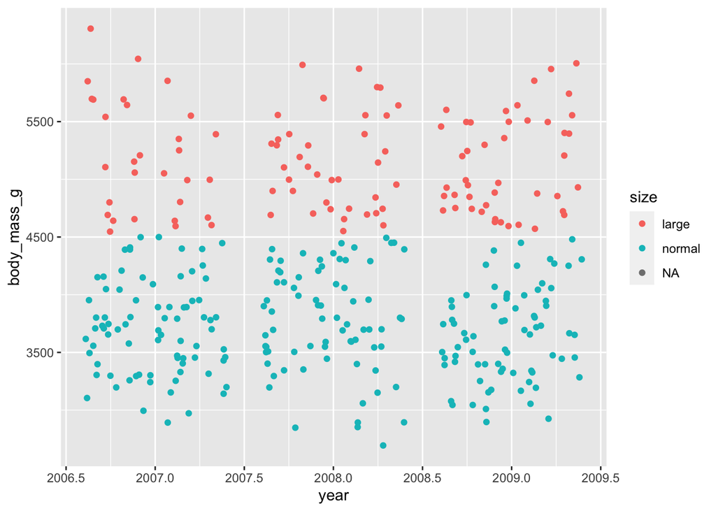

```r
penguins %>%
  mutate(size = if_else(condition = body_mass_g > 4500,
                        true = "large",
                        false = "normal")) %>%
  ggplot() +
  geom_jitter(mapping = aes(x = year, y = body_mass_g, colour = size))
```

That shows us clearly that we have grouped the penguins based on their size. But there is this strange `NA` in the plot legend. what is that?

In R, missing values are usually given the value `NA` which stands for `Not applicable`, *i.e.*, missing data. This is a very special name in R. Like `TRUE` and `FALSE` are capitalized, RStudio immediately recognizes the combination of capital letters and gives it another color than all other values.

# Adding new variables, part three

Now we know how to create new variables, and even how to make them if there are conditions on how to add the data.

But, we often want to add several columns of different types, and maybe even add new variables based on other new columns! Oh, it’s starting to sound complicated, but it does not have to be!

`mutate()` is so-called lazy-evaluated. This sounds weird, but it means that each new column you make is made in the sequence you make them. So as long as you think about the order of your `mutate()` creations, you can do that in a single mutate call.

```r
penguins %>%
  mutate(bill_ratio = bill_depth_mm / bill_length_mm,
         bill_type = if_else(condition = bill_ratio < 0.5,
                             true = "elongated",
                             false = "stumped")) %>%
  select(starts_with("bill"))
```

```
## # A tibble: 344 x 4
##    bill_length_mm bill_depth_mm bill_ratio bill_type
##             <dbl>         <dbl>      <dbl> <chr>
##  1           39.1          18.7      0.478 elongated
##  2           39.5          17.4      0.441 elongated
##  3           40.3          18        0.447 elongated
##  4           NA            NA       NA     <NA>
##  5           36.7          19.3      0.526 stumped
##  6           39.3          20.6      0.524 stumped
##  7           38.9          17.8      0.458 elongated
##  8           39.2          19.6      0.5   stumped
##  9           34.1          18.1      0.531 stumped
## 10           42            20.2      0.481 elongated
## # … with 334 more rows
```

Now you’ve created two variables. One for `bill_ratio`, and then another one conditional on the values of the `bill_ratio`.

If you switched the order of these two, R would produce an error, because there would be no bill ratio to create the other column.

```r
penguins %>%
  mutate(bill_type = if_else(condition = bill_ratio < 0.5,
                             true = "elongated",
                             false = "stumped"),
         bill_ratio = bill_depth_mm / bill_length_mm) %>%
  select(starts_with("bill"))
```

```
## Error: Problem with `mutate()` column `bill_type`.
## ℹ `bill_type = if_else(condition = bill_ratio < 0.5, true = "elongated", false = "stumped")`.
## x object 'bill_ratio' not found
```

But what if we want to categorize based on more than one condition? Nested `if_else()`?

```r
penguins %>%
  mutate(
    bill_ratio = bill_depth_mm / bill_length_mm,
    bill_type = if_else(condition = bill_ratio < 0.35,
                        true =  "elongated",
                        false = if_else(condition = bill_ratio < 0.45,
                                        true = "normal",
                                        false = "stumped"))) %>%
  select(starts_with("bill"))
```

```
## # A tibble: 344 x 4
##    bill_length_mm bill_depth_mm bill_ratio bill_type
##             <dbl>         <dbl>      <dbl> <chr>
##  1           39.1          18.7      0.478 stumped
##  2           39.5          17.4      0.441 normal
##  3           40.3          18        0.447 normal
##  4           NA            NA       NA     <NA>
##  5           36.7          19.3      0.526 stumped
##  6           39.3          20.6      0.524 stumped
##  7           38.9          17.8      0.458 stumped
##  8           39.2          19.6      0.5   stumped
##  9           34.1          18.1      0.531 stumped
## 10           42            20.2      0.481 stumped
## # … with 334 more rows
```

what if you have even more conditionals? Thankfully, {dplyr} has a smarter way of doing this, called `case_when()`. This function is similar to `if_else()`, but where you specify what each condition should be assigned. On the left you have the logical expression, and the on the right of the tilde (`~`) is the value to be assigned if that expression is `TRUE`

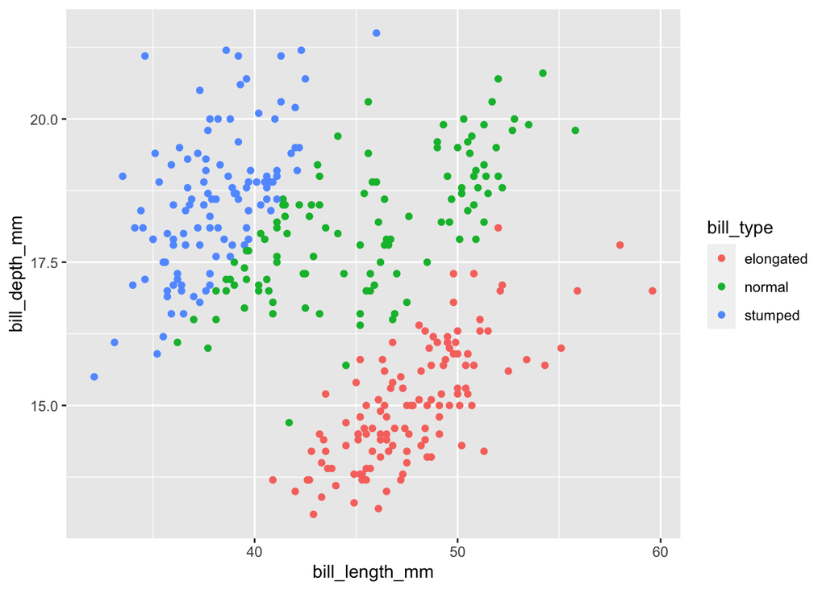

```r
penguins %>%
  mutate(
    bill_ratio = bill_depth_mm / bill_length_mm,
    bill_type = case_when(bill_ratio < 0.35 ~ "elongated",
                          bill_ratio < 0.45 ~ "normal",
                          TRUE ~ "stumped")) %>%
  ggplot(mapping = aes(x = bill_length_mm,
                       y = bill_depth_mm,
                       colour = bill_type)) +
  geom_point()
```

That looks almost the same. The `NA`’s are gone! That’s not right. We cannot categorize values that are missing. It’s our last statement that does this, which just says “make the remainder this value”. Which is not what we want. We need the `NA`s to stay `NA`’s.

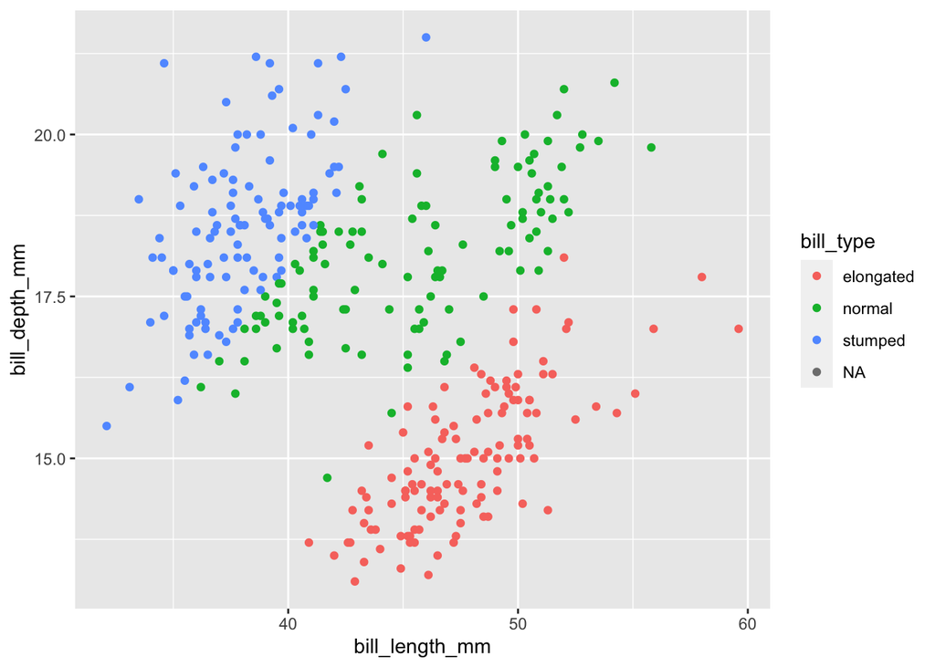

```r
penguins %>%
  mutate(
    bill_ratio = bill_depth_mm / bill_length_mm,
    bill_type = case_when(bill_ratio < 0.35 ~ "elongated",
                          bill_ratio < 0.45 ~ "normal",
                          !is.na(bill_ratio) ~ "stumped")) %>%
  ggplot(mapping = aes(x = bill_length_mm,
                       y = bill_depth_mm,
                       colour = bill_type)) +
  geom_point()
```

Here, we use the `is.na()` function we saw earlier, on `bill_ratio`. But it also has an `!` in front, what does that mean? In R’s logical expressions, the `!` is a negation specifier. It means it flips the logical so the `TRUE` becomes `FALSE`, and *vice versa*. So here, it means the `bill_ratio` is **not** `NA`.

# Adding new variables, part four

So far, we’ve been looking at adding variables one by one. This is of course something we do all the time, but some times we need to do the same change to multiple columns at once. Imagine you have a data set with 20 column and you want to scale them all to the same scale. Writing the same command with different columns 20 times is very tedious. It is now the {dplyr} package truly starts to shine!

In our case, let us say we want to scale the three columns with millimeter measurements so that they have a mean of 0 and standard deviation of 1. We’ve already used the `scale()` function once before, so we will do it again.

In this simple example we might have done so:

```r
penguins %>%
  mutate(bill_depth_sc = scale(bill_depth_mm),
         bill_length_sc = scale(bill_length_mm),
         flipper_length_sc = scale(flipper_length_mm))
```

```
## # A tibble: 344 x 11
##    species island    bill_length_mm bill_depth_mm flipper_length_mm body_mass_g
##    <fct>   <fct>              <dbl>         <dbl>             <int>       <int>
##  1 Adelie  Torgersen           39.1          18.7               181        3750
##  2 Adelie  Torgersen           39.5          17.4               186        3800
##  3 Adelie  Torgersen           40.3          18                 195        3250
##  4 Adelie  Torgersen           NA            NA                  NA          NA
##  5 Adelie  Torgersen           36.7          19.3               193        3450
##  6 Adelie  Torgersen           39.3          20.6               190        3650
##  7 Adelie  Torgersen           38.9          17.8               181        3625
##  8 Adelie  Torgersen           39.2          19.6               195        4675
##  9 Adelie  Torgersen           34.1          18.1               193        3475
## 10 Adelie  Torgersen           42            20.2               190        4250
## # … with 334 more rows, and 5 more variables: sex <fct>, year <int>,
## #   bill_depth_sc <dbl[,1]>, bill_length_sc <dbl[,1]>,
## #   flipper_length_sc <dbl[,1]>
```

Its just three columns, we can do that. But let us imagine we have 20 of these, typing all that out is tedious and error prone. You might forget to alter the name or keep the same type of naming convention. We are only human, we easily make mistakes.

With {dplyr}’s `across()` we can combine our knowledge of tidy-selectors and mutate to create the entire transformation for these columns at once.

```r
penguins %>%
  mutate(across(.cols = ends_with("mm"),
                .fns = scale))
```

```
## # A tibble: 344 x 8
##    species island bill_length_mm[… bill_depth_mm[,… flipper_length_… body_mass_g
##    <fct>   <fct>             <dbl>            <dbl>            <dbl>       <int>
##  1 Adelie  Torge…           -0.883            0.784           -1.42         3750
##  2 Adelie  Torge…           -0.810            0.126           -1.06         3800
##  3 Adelie  Torge…           -0.663            0.430           -0.421        3250
##  4 Adelie  Torge…           NA               NA               NA              NA
##  5 Adelie  Torge…           -1.32             1.09            -0.563        3450
##  6 Adelie  Torge…           -0.847            1.75            -0.776        3650
##  7 Adelie  Torge…           -0.920            0.329           -1.42         3625
##  8 Adelie  Torge…           -0.865            1.24            -0.421        4675
##  9 Adelie  Torge…           -1.80             0.480           -0.563        3475
## 10 Adelie  Torge…           -0.352            1.54            -0.776        4250
## # … with 334 more rows, and 2 more variables: sex <fct>, year <int>
```

Whoa! So fast and so simple! Now the three columns are scaled. But oh no! The columns have been overwritten. Rather than creating new ones, we replaced the old ones.

This might be your intention in some instances, or maybe you will just create a new data set with the scaled variables.

```r
penguins_mm_sc <- penguins %>%
  mutate(across(.cols = ends_with("mm"),
                .fns = scale))
```

but often, we’d like to keep the original but add the new variants. We can do that to within the across!

```r
penguins %>%
  mutate(across(.cols = ends_with("mm"),
                .fns = scale,
                .names = "{.col}_sc")) %>%
  select(contains("mm"))
```

```
## # A tibble: 344 x 6
##    bill_length_mm bill_depth_mm flipper_length_mm bill_length_mm_sc[,1]
##             <dbl>         <dbl>             <int>                 <dbl>
##  1           39.1          18.7               181                -0.883
##  2           39.5          17.4               186                -0.810
##  3           40.3          18                 195                -0.663
##  4           NA            NA                  NA                NA
##  5           36.7          19.3               193                -1.32
##  6           39.3          20.6               190                -0.847
##  7           38.9          17.8               181                -0.920
##  8           39.2          19.6               195                -0.865
##  9           34.1          18.1               193                -1.80
## 10           42            20.2               190                -0.352
## # … with 334 more rows, and 2 more variables: bill_depth_mm_sc <dbl[,1]>,
## #   flipper_length_mm_sc <dbl[,1]>
```

Now they are all there! neat! But that `.names` argument is a little weird. What does it really mean?

Internally, `across()` stores the column names in a vector it calls `.col`. We can use this knowledge to tell the across function what to name our new columns. In this case, we want to append the column name with `_sc`.

## **Adding new variables, challenges**

### Assignment

Room: Break-out  
Duration: 10 minutes

> **1a**: Create a column named `bill_ld_ratio_log` that is the natural logarithm (using the `log()` function) of `bill_length_mm` divided by `bill_depth_mm`

> **1b**: Create a new column called `body_type`, where animals below 3 kg are `small`, animals between 3 and 4.5 kg are `normal`, and animals larger than 4.5 kg are `large`. In the same command, create a new column named `biscoe` and its content should be `TRUE` if the island is `Biscoe` and `FALSE` for everything else.

> **1c**: Transform all the colmns with milimetres measurements so they are scaled, and add the *prefix* `sc_` to the columns names.

### Solution

```r
## 1a
penguins %>%
  mutate(bill_ld_ratio_log = log(bill_length_mm / bill_depth_mm))
```

```
## # A tibble: 344 x 9
##    species island    bill_length_mm bill_depth_mm flipper_length_mm body_mass_g
##    <fct>   <fct>              <dbl>         <dbl>             <int>       <int>
##  1 Adelie  Torgersen           39.1          18.7               181        3750
##  2 Adelie  Torgersen           39.5          17.4               186        3800
##  3 Adelie  Torgersen           40.3          18                 195        3250
##  4 Adelie  Torgersen           NA            NA                  NA          NA
##  5 Adelie  Torgersen           36.7          19.3               193        3450
##  6 Adelie  Torgersen           39.3          20.6               190        3650
##  7 Adelie  Torgersen           38.9          17.8               181        3625
##  8 Adelie  Torgersen           39.2          19.6               195        4675
##  9 Adelie  Torgersen           34.1          18.1               193        3475
## 10 Adelie  Torgersen           42            20.2               190        4250
## # … with 334 more rows, and 3 more variables: sex <fct>, year <int>,
## #   bill_ld_ratio_log <dbl>
```

```r
## 1b
penguins %>%
  mutate(body_type = case_when(body_mass_g < 3000 ~ "small",
                               body_mass_g >= 3000 & body_mass_g < 4500 ~ "normal",
                               body_mass_g >= 4500 ~ "large"),
         biscoe = if_else(condition = island == "Biscoe",
                          true = TRUE,
                          false = FALSE))
```

```
## # A tibble: 344 x 10
##    species island    bill_length_mm bill_depth_mm flipper_length_mm body_mass_g
##    <fct>   <fct>              <dbl>         <dbl>             <int>       <int>
##  1 Adelie  Torgersen           39.1          18.7               181        3750
##  2 Adelie  Torgersen           39.5          17.4               186        3800
##  3 Adelie  Torgersen           40.3          18                 195        3250
##  4 Adelie  Torgersen           NA            NA                  NA          NA
##  5 Adelie  Torgersen           36.7          19.3               193        3450
##  6 Adelie  Torgersen           39.3          20.6               190        3650
##  7 Adelie  Torgersen           38.9          17.8               181        3625
##  8 Adelie  Torgersen           39.2          19.6               195        4675
##  9 Adelie  Torgersen           34.1          18.1               193        3475
## 10 Adelie  Torgersen           42            20.2               190        4250
## # … with 334 more rows, and 4 more variables: sex <fct>, year <int>,
## #   body_type <chr>, biscoe <lgl>
```

```r
## 1c
penguins %>%
  mutate(across(.cols = ends_with("mm"),
                .fns = scale,
                .names = "sc_{.col}")) %>%
  select(contains("mm"))
```

```
## # A tibble: 344 x 6
##    bill_length_mm bill_depth_mm flipper_length_mm sc_bill_length_mm[,1]
##             <dbl>         <dbl>             <int>                 <dbl>
##  1           39.1          18.7               181                -0.883
##  2           39.5          17.4               186                -0.810
##  3           40.3          18                 195                -0.663
##  4           NA            NA                  NA                NA
##  5           36.7          19.3               193                -1.32
##  6           39.3          20.6               190                -0.847
##  7           38.9          17.8               181                -0.920
##  8           39.2          19.6               195                -0.865
##  9           34.1          18.1               193                -1.80
## 10           42            20.2               190                -0.352
## # … with 334 more rows, and 2 more variables: sc_bill_depth_mm <dbl[,1]>,
## #   sc_flipper_length_mm <dbl[,1]>
```

# Wrap up